# Predictive models

Jim Costello

7/16/2025

#### Contents:

Note that you will need the following packages * caret * glmnet * reshape2 * gplots

### Load Cytokine data and clinial information

The data we will use were collected from individuals with and without Down sydrome. The samples are from blood plasma and cytokine data were generated for each individual.

```r
# define the file paths to the input data
htp_meta_data_file <- here("2025/data", "HTP_Metadata_v0.5_Synapse.txt")
htp_cytokines_data_file <- here("2025/data", "HTP_MSD_Cytokines_Synapse.txt")

# Other parameters
# standard_colors <- c("Group1" = "#F8766D", "Group2" = "#00BFC4")
standard_colors <- c("Control" = "gray60", "T21" = "#009b4e")
out_file_prefix <- "linear_regression_htp_cytokines_v0.1_"
# End required parameters ###


# 1 Read in and inspect data ----
## 1.1 Read in meta data ----
htp_meta_data <- htp_meta_data_file |>
  read_tsv() |>
  mutate(
    Karyotype = fct_relevel(Karyotype, c("Control", "T21")), # convert to factor and set order
    Sex = fct_relevel(Sex, "Female"), # convert to factor and set order
    Sample_source_code = as_factor(Sample_source_code) # convert to factor - default is numerical order
  )
# inspect
htp_meta_data
```

```
## # A tibble: 1,010 × 14
##    ParticipantID LabID     Karyotype Sex      Age Weight_kg Height_cm
##    <chr>         <chr>     <fct>     <fct>  <dbl>     <dbl>     <dbl>
##  1 HTP0274       HTP0274A  T21       Male    17.5      45.3      157
##  2 HTP0591       HTP0591A  T21       Male    31.9      72.8      154.
##  3 HTP0330       HTP0330A  T21       Male     6.1      16.8      102.
##  4 HTP0278       HTP0278A  T21       Male     7.6      22.5       NA
##  5 HTP0052       HTP0052A  T21       Female  28.7      51.3      133.
##  6 HTP0052       HTP0052A2 T21       Female  29.9      50.9      134.
##  7 HTP0052       HTP0052A3 T21       Female  31        49.7      133
##  8 HTP0678       HTP0678B  Control   Female  17.1      45        155
##  9 HTP0709       HTP0709B  Control   Female  29.1      58.4      160.
## 10 HTP0236       HTP0236A  T21       Male    10.4      NA         NA
## # ℹ 1,000 more rows
## # ℹ 7 more variables: Sample_source_code <fct>, Event_name <chr>, Race <chr>,
## #   Ethnicity <chr>, Data_contact <chr>, Date_exported <chr>, Script <chr>
```

```r
htp_meta_data |> skimr::skim()
```

Data summary

| Name | htp_meta_data |
| --- | --- |
| Number of rows | 1010 |
| Number of columns | 14 |
| _______________________ |  |
| Column type frequency: |  |
| character | 8 |
| factor | 3 |
| numeric | 3 |
| ________________________ |  |
| Group variables | None |

**Variable type: character**

| skim_variable | n_missing | complete_rate | min | max | empty | n_unique | whitespace |
| --- | --- | --- | --- | --- | --- | --- | --- |
| ParticipantID | 0 | 1.00 | 7 | 7 | 0 | 683 | 0 |
| LabID | 0 | 1.00 | 8 | 10 | 0 | 1010 | 0 |
| Event_name | 0 | 1.00 | 7 | 8 | 0 | 10 | 0 |
| Race | 8 | 0.99 | 5 | 41 | 0 | 8 | 0 |
| Ethnicity | 8 | 0.99 | 6 | 22 | 0 | 4 | 0 |
| Data_contact | 0 | 1.00 | 32 | 32 | 0 | 1 | 0 |
| Date_exported | 0 | 1.00 | 8 | 8 | 0 | 1 | 0 |
| Script | 0 | 1.00 | 23 | 23 | 0 | 1 | 0 |

**Variable type: factor**

| skim_variable | n_missing | complete_rate | ordered | n_unique | top_counts |
| --- | --- | --- | --- | --- | --- |
| Karyotype | 0 | 1 | FALSE | 2 | T21: 641, Con: 369 |
| Sex | 0 | 1 | FALSE | 2 | Fem: 555, Mal: 455 |
| Sample_source_code | 0 | 1 | FALSE | 9 | 1: 542, 6: 161, 3: 134, 2: 74 |

**Variable type: numeric**

| skim_variable | n_missing | complete_rate | mean | sd | p0 | p25 | p50 | p75 | p100 | hist |
| --- | --- | --- | --- | --- | --- | --- | --- | --- | --- | --- |
| Age | 0 | 1.00 | 27.63 | 15.13 | 0.5 | 17.00 | 26.6 | 36.0 | 82.5 | ▅▇▃▂▁ |
| Weight_kg | 169 | 0.83 | 64.70 | 25.11 | 6.7 | 51.60 | 65.8 | 79.7 | 149.6 | ▂▆▇▂▁ |
| Height_cm | 175 | 0.83 | 152.25 | 21.91 | 64.0 | 145.25 | 155.0 | 166.0 | 196.0 | ▁▁▂▇▂ |

```r
#
here("2025/data", "HTP_Metadata_v0.5_dictionary.txt") |> read_tsv()
```

```
## # A tibble: 14 × 3
##    Variable           Example                 Description
##    <chr>              <chr>                   <chr>
##  1 ParticipantID      HTP0274                 Human Trisome Project participant…
##  2 LabID              HTP0274A                Human Trisome Project sample/bios…
##  3 Karyotype          T21                     Trisomy 21 status; trisomy 21/Dow…
##  4 Sex                Female                  Biological sex
##  5 Age                17.5                    Age at blood draw in years
##  6 Weight_kg          45.3                    Weight at blood draw in kilograms
##  7 Height_cm          157                     Height at blood draw in centimetr…
##  8 Sample_source_code 6                       Anonymous collection site identif…
##  9 Event_name         Visit 1                 Longitudinal visit/blood draw ide…
## 10 Race               White                   Self-reported race
## 11 Ethnicity          Not Hispanic or Latino  Self-reported ethnicity
## 12 Data_contact       email address           Contact for queries about data set
## 13 Date_exported      06012022                Date of data set preparation/expo…
## 14 Script             HTP_data_Synapse_v0.1.R Data preparation script
```

```r
#

## 1.2 Read in abundance data ----
htp_cytokines_data <- htp_cytokines_data_file |>
  read_tsv()
  # janitor::clean_names(case = "none")
# inspect
htp_cytokines_data # 25,758 rows
```

```
## # A tibble: 25,758 × 11
##    LabID    Sample_type Platform Batch Analyte     Units   Value N_imputed_wells
##    <chr>    <chr>       <chr>    <dbl> <chr>       <chr>   <dbl>           <dbl>
##  1 HTP0001B Plasma      MSD          3 CRP         pg/mL 3.22e+6               0
##  2 HTP0001B Plasma      MSD          3 Eotaxin     pg/mL 7.81e+1               0
##  3 HTP0001B Plasma      MSD          3 Eotaxin-3   pg/mL 1.20e+1               0
##  4 HTP0001B Plasma      MSD          3 FGF (basic) pg/mL 9.43e+0               0
##  5 HTP0001B Plasma      MSD          3 GM-CSF      pg/mL 3.19e-1               0
##  6 HTP0001B Plasma      MSD          3 ICAM-1      pg/mL 2.31e+5               0
##  7 HTP0001B Plasma      MSD          3 IFN-alpha2a pg/mL 9.29e-1               0
##  8 HTP0001B Plasma      MSD          3 IFN-beta    pg/mL 1.10e+1               2
##  9 HTP0001B Plasma      MSD          3 IFN-gamma   pg/mL 2.28e+0               0
## 10 HTP0001B Plasma      MSD          3 IL-10       pg/mL 3.06e-1               0
## # ℹ 25,748 more rows
## # ℹ 3 more variables: Data_contact <chr>, Date_exported <chr>, Script <chr>
```

```r
htp_cytokines_data |> skimr::skim()
```

Data summary

| Name | htp_cytokines_data |
| --- | --- |
| Number of rows | 25758 |
| Number of columns | 11 |
| _______________________ |  |
| Column type frequency: |  |
| character | 8 |
| numeric | 3 |
| ________________________ |  |
| Group variables | None |

**Variable type: character**

| skim_variable | n_missing | complete_rate | min | max | empty | n_unique | whitespace |
| --- | --- | --- | --- | --- | --- | --- | --- |
| LabID | 0 | 1 | 8 | 9 | 0 | 477 | 0 |
| Sample_type | 0 | 1 | 6 | 6 | 0 | 1 | 0 |
| Platform | 0 | 1 | 3 | 3 | 0 | 1 | 0 |
| Analyte | 0 | 1 | 3 | 14 | 0 | 54 | 0 |
| Units | 0 | 1 | 5 | 5 | 0 | 1 | 0 |
| Data_contact | 0 | 1 | 32 | 32 | 0 | 1 | 0 |
| Date_exported | 0 | 1 | 8 | 8 | 0 | 1 | 0 |
| Script | 0 | 1 | 23 | 23 | 0 | 1 | 0 |

**Variable type: numeric**

| skim_variable | n_missing | complete_rate | mean | sd | p0 | p25 | p50 | p75 | p100 | hist |
| --- | --- | --- | --- | --- | --- | --- | --- | --- | --- | --- |
| Batch | 0 | 1 | 4.98 | 1.08 | 3 | 4.00 | 5.00 | 6.00 | 6 | ▃▂▁▆▇ |
| Value | 0 | 1 | 392846.59 | 5960600.07 | 0 | 0.61 | 5.22 | 106.11 | 380639855 | ▇▁▁▁▁ |
| N_imputed_wells | 0 | 1 | 0.19 | 0.54 | 0 | 0.00 | 0.00 | 0.00 | 4 | ▇▁▁▁▁ |

```r
htp_cytokines_data |> distinct(Analyte) # 54 Analytes
```

```
## # A tibble: 54 × 1
##    Analyte
##    <chr>
##  1 CRP
##  2 Eotaxin
##  3 Eotaxin-3
##  4 FGF (basic)
##  5 GM-CSF
##  6 ICAM-1
##  7 IFN-alpha2a
##  8 IFN-beta
##  9 IFN-gamma
## 10 IL-10
## # ℹ 44 more rows
```

```r
htp_cytokines_data |> distinct(LabID) # 477 LabIDs
```

```
## # A tibble: 477 × 1
##    LabID
##    <chr>
##  1 HTP0001B
##  2 HTP0003A
##  3 HTP0005A
##  4 HTP0008B
##  5 HTP0012A
##  6 HTP0015A
##  7 HTP0017A
##  8 HTP0018B
##  9 HTP0019B2
## 10 HTP0020A
## # ℹ 467 more rows
```

```r
#
here("2025/data", "HTP_MSD_Cytokines_dictionary.txt") |> read_tsv()
```

```
## # A tibble: 11 × 3
##    Variable        Example                             Description
##    <chr>           <chr>                               <chr>
##  1 LabID           HTP0677B                            Human Trisome Project sa…
##  2 Sample_type     Plasma                              Type of sample taken/ext…
##  3 Platform        MSD                                 Description of assay pla…
##  4 Batch           Sample processing/measurement batch <NA>
##  5 Analyte         FGF (basic)                         Analyte name
##  6 Units           pg/mL                               Description of measureme…
##  7 Value           1.319083834                         Measurement value
##  8 N_imputed_wells 1                                   Number of out-of-range w…
##  9 Data_contact    email address                       Contact for queries abou…
## 10 Date_exported   11102021                            Date of data set prepara…
## 11 Script          HTP_data_Synapse_v0.1.R             Data preparation script
```

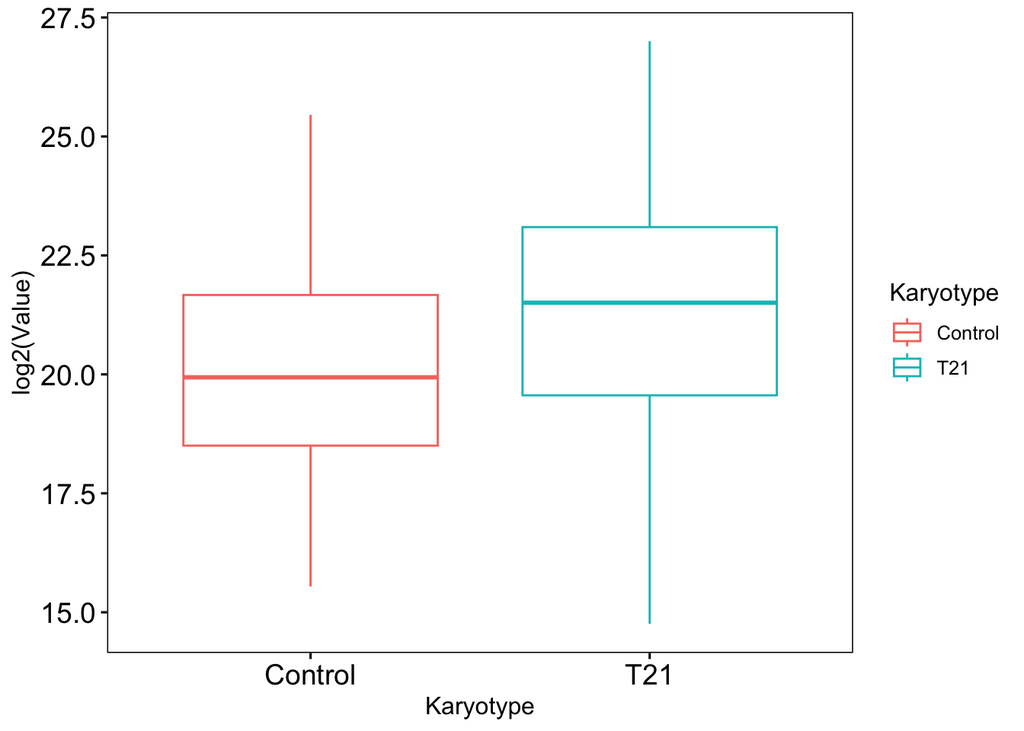

```r
#

## 1.3 Join meta data with data type 1 and data type 2 ----
htp_meta_cytokines_data <- htp_cytokines_data |>
  inner_join(htp_meta_data, by="LabID")
# check number of rows returned !!!


# 2 Data exploration  ----
## 2.1 basic check of data distribution(s) ----
htp_meta_cytokines_data |>
  filter(Analyte == "CRP") |>
  ggplot(aes(Karyotype, log2(Value), color = Karyotype)) +
  geom_boxplot()
```

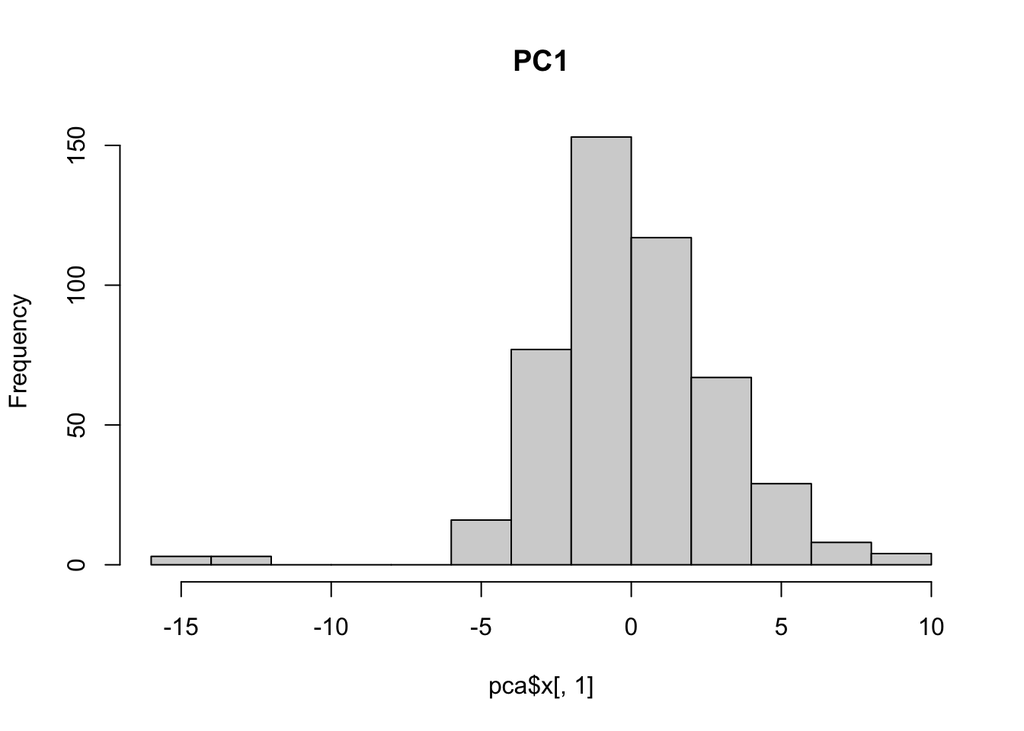

```r
#

#create a data.frame of individuals by cytokines
cytokines_df <- as.data.frame(pivot_wider(htp_meta_cytokines_data, names_from = "Analyte", values_from = "Value", id_cols = "LabID"))
row.names(cytokines_df) <- cytokines_df$LabID
cytokines_df <- log2(cytokines_df[,-1])

# extract the annotations for each of the samples
pca_annos <- as.data.frame(htp_meta_data %>% filter(LabID %in% row.names(cytokines_df)))
row.names(pca_annos) <- pca_annos$LabID
pca_annos <- pca_annos[row.names(cytokines_df),]

# create a dataframe that will be used for plots that contains the cytokine and patient information.
cytokines_df_annos <- cbind(cytokines_df, pca_annos)

# PCA with HTP Cytokine data
pca <- prcomp(na.omit(cytokines_df), scale=T)

# remove outlier samples
hist(pca$x[,1], main ="PC1")
```

```r
sort(pca$x[,1])
```

[output not shown]

[output cut: 137 more lines]

[output not shown]

```r
row.names(cytokines_df)[pca$x[,1] < -10]
```

```
## [1] "HTP0553A" "HTP0555B" "HTP0565A" "HTP0572A" "HTP0589A" "HTP0664A"
```

```r
cytokines_df <- cytokines_df[pca$x[,1] > -10,]
cytokines_df_annos <- cytokines_df_annos[pca$x[,1] > -10,]
dim(cytokines_df)
```

```
## [1] 471  54
```

```r
dim(cytokines_df_annos)
```

```
## [1] 471  68
```

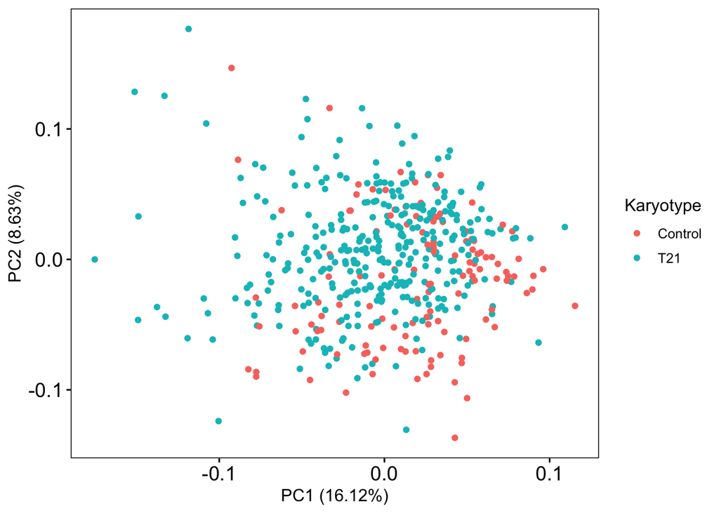

```r
pca <- prcomp(na.omit(cytokines_df), scale=T)
autoplot(pca, data=cytokines_df_annos, col='Karyotype')
```

### Hierarchical Clustering

Note: Make sure you install the `hclust` package in R. Some of the code is taken from this nice [tutorial post](https://bradleyboehmke.github.io/HOML/hierarchical.html) on hierarchical clustering.

```r
# we will first perform agglomerative hierachical clustering (bottom up) using the agnes function in the cluster package

# test the various linkage methods to see which provides the strongest clusters
#define linkage methods
m <- c( "average", "single", "complete", "ward")
names(m) <- c( "average", "single", "complete", "ward")

#function to compute agglomerative coefficient
ac <- function(x) {
  agnes(scale(cytokines_df), method = x)$ac
}

#calculate agglomerative coefficient for each clustering linkage method
sapply(m, ac)
```

```
##   average    single  complete      ward
## 0.6524365 0.5456719 0.7355718 0.8913438
```

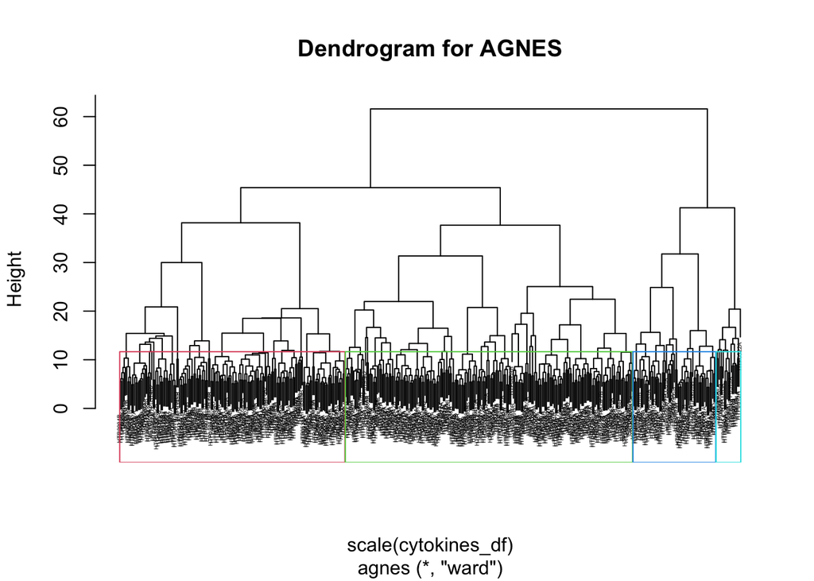

```r
#generate the agglomerative clustering and perform some visualizations
ac <- agnes(scale(cytokines_df), method="ward")
plot(as.hclust(ac), cex=0.3, main="Dendrogram for AGNES")
rect.hclust(ac, k = 4, border = 2:5)
```

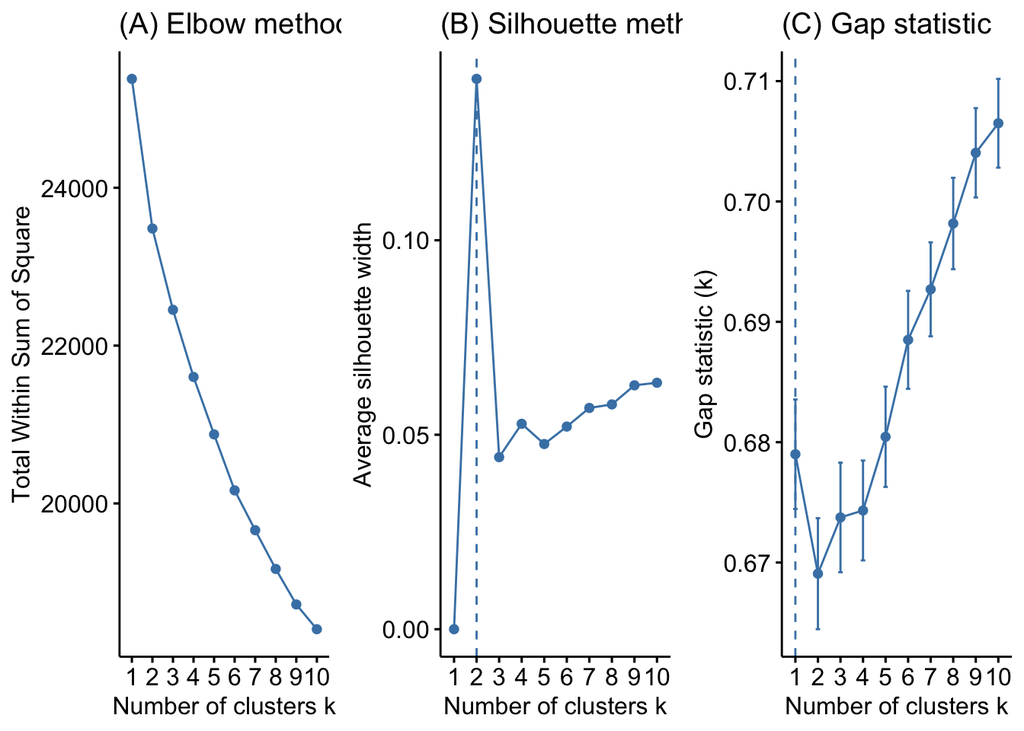

```r
# lets see how we can determine the appropriate cluster size

# The total within-cluster sum of square (wss) measures the compactness of the clustering and we want it to be as small as possible.
p1 <- fviz_nbclust(scale(cytokines_df), FUN = hcut, method = "wss",
                   k.max = 10) +
  ggtitle("(A) Elbow method")
# silhouette method determines how well each object lies within its cluster. A high average silhouette width indicates a good clustering.
p2 <- fviz_nbclust(scale(cytokines_df), FUN = hcut, method = "silhouette",
                   k.max = 10) +
  ggtitle("(B) Silhouette method")
# The gap statistic compares the total intracluster variation for different values of k with their expected values under null reference distribution of the data (i.e. a distribution with no obvious clustering). The reference dataset is generated using Monte Carlo simulations of the sampling process.
p3 <- fviz_nbclust(scale(cytokines_df), FUN = hcut, method = "gap_stat",
                   k.max = 10) +
  ggtitle("(C) Gap statistic")
gridExtra::grid.arrange(p1, p2, p3, nrow = 1)
```

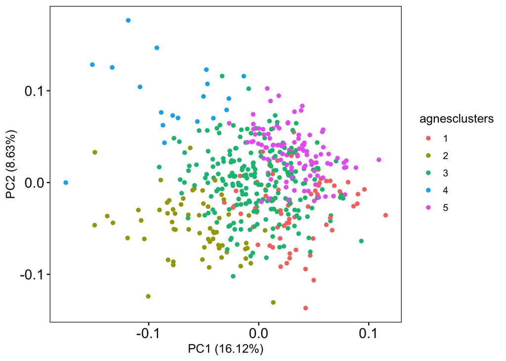

```r
# lets see where the clusters fall in PCA space
cytokines_df_annos$agnesclusters <- as.factor(cutree(ac, k=5))
autoplot(pca, data=cytokines_df_annos, col='agnesclusters')
```

```r
# we will next perform divisive hierarchical clustering (top down) using the diana function in the cluster package
di <- diana(scale(cytokines_df))
di$dc
```

```
## [1] 0.7191096
```

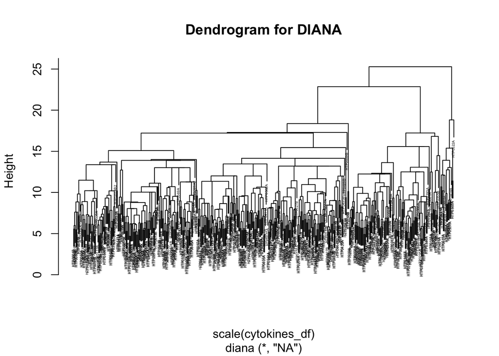

```r
plot(as.hclust(di), cex=0.3, main="Dendrogram for DIANA")
```

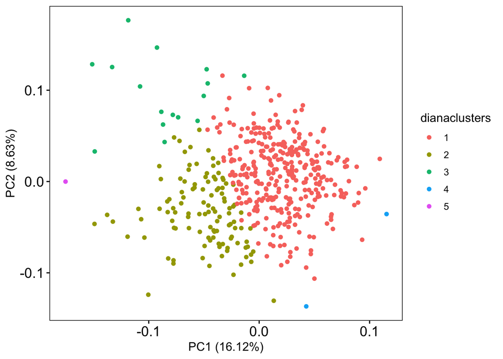

```r
cytokines_df_annos$dianaclusters <- as.factor(cutree(di, k=5))
autoplot(pca, data=cytokines_df_annos, col='dianaclusters')
```

### Linear Models

Note: Make sure you install the `glmnet` package in R. We will use this for all examples of Ridge, Lasso and elastic net regression.

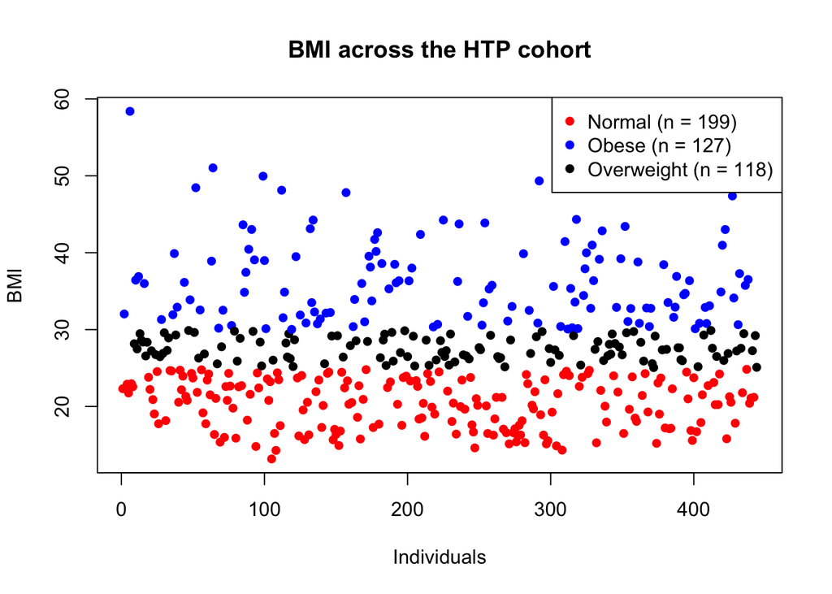

```r
# we will predict on BMI, so remove individuals without any BMI information.
cytokines_df_annos$BMI <- cytokines_df_annos$Weight_kg/(cytokines_df_annos$Height_cm/100)^2
cytokines_df <- cytokines_df[!is.na(cytokines_df_annos$BMI),]
cytokines_df_annos <- cytokines_df_annos[!is.na(cytokines_df_annos$BMI),]

######## Organize the data for fitting linear models:
response = cytokines_df_annos$BMI

# Define cutoffs. We will use standard BMI scales to define normal, overweight, obese
normal.cutoff =  25
obese.cutoff = 30

# Append response variable to matrix
cytokines_df_annos$Response = ifelse(response >= obese.cutoff, 'obese',
                          ifelse(response <= normal.cutoff, 'normal', 'overweight'))

# Save group sizes for comparison
tab = table(cytokines_df_annos$Response)

# Check plot to make sure our cutoffs look reasonable
group.colors = ifelse(cytokines_df_annos$Response == 'obese', 'blue',
                      ifelse(cytokines_df_annos$Response == 'normal', 'red', 'black'))

plot(response, col = group.colors, pch = 16,
     main = 'BMI across the HTP cohort',
     xlab = 'Individuals',
     ylab = 'BMI')
legend('topright', pch = 16, col = c('red', 'blue', 'black'),
       legend = c(paste0(sprintf('Normal (n = %d)', tab['normal'])),
                  paste0(sprintf('Obese (n = %d)', tab['obese'])),
                  paste0(sprintf('Overweight (n = %d)', tab['overweight']))))
```

```r
# Filter out the overweight and make the two responses a factor
cytokines_df = cytokines_df[cytokines_df_annos$Response != 'overweight',]
cytokines_df_annos = cytokines_df_annos[cytokines_df_annos$Response != 'overweight',]
cytokines_df$Response <- factor(cytokines_df_annos$Response)
table(cytokines_df$Response)
```

```
##
## normal  obese
##    199    127
```

```r
# Define train and test sets
individuals = row.names(cytokines_df)
train.percent = .75
inTrain = individuals %in% sample(individuals, floor(train.percent*length(individuals)))
train.data = cytokines_df[inTrain,]
test.data = cytokines_df[!inTrain,]

# Make sure we have enough of each group in test set
table(test.data$Response)
```

```
##
## normal  obese
##     49     33
```

```r
table(train.data$Response)
```

```
##
## normal  obese
##    150     94
```

#### Example 1 - Ridge regression

```r
# Make feature matrix and response vector
feature.matrix = as.matrix(train.data[,-ncol(train.data)])  # Exclude the last column (Response)
response.vector = train.data$Response

# Fit linear Ridge regression model
ridge.fit = glmnet(x = feature.matrix,      # features = all cytokines
                   y = response.vector,     # binary  response
                   family = 'binomial',     # we are doing binary classification
                   alpha = 0)               # alpha = 0 is the Ridge penalty

# Use the fit model to predict on the testing data
testing.matrix= as.matrix(test.data[,-ncol(test.data)]) # Exclude the last column (Response)
testing.response = test.data$Response
ridge.preds = predict(ridge.fit, newx = testing.matrix, type = 'class')

# Take a look at how our model did
table(Predicted_Group = ridge.preds[,ncol(ridge.preds)],
      Actual_Group = test.data$Response)
```

```
##                Actual_Group
## Predicted_Group normal obese
##          normal     41    15
##          obese       8    18
```

```r
ReportPerfMetrics = function(predicted.labels, true.labels, pos.class){
  # Calculate the accuracy, precision and recall for two-class prediction
  tp = sum(true.labels == pos.class & predicted.labels == pos.class)
  fp = sum(true.labels != pos.class & predicted.labels == pos.class)
  tn = sum(true.labels != pos.class & predicted.labels != pos.class)
  fn = sum(true.labels == pos.class & predicted.labels != pos.class)
  n = tp + fp + tn + fn

  accuracy = (tp + tn)/n
  precision = tp/(tp + fp)
  recall = tp/(tp + fn)

  return(list(Accuracy = accuracy, Precision = precision, Recall = recall))
}

ridge.metrics = ReportPerfMetrics(ridge.preds[,ncol(ridge.preds)], test.data$Response, 'obese')
ridge.metrics
```

```
## $Accuracy
## [1] 0.7195122
##
## $Precision
## [1] 0.6923077
##
## $Recall
## [1] 0.5454545
```

#### Example 2 - Lasso regression

```r
# Fit linear Lasso regression model
lasso.fit = glmnet(x = feature.matrix,      # features = all cytokines
                   y = response.vector,     # binary response
                   family = 'binomial',     # we are doing binary classification
                   alpha = 1)               # alpha = 1 is the Lasso penalty

# Use the fit model to predict on the testing data
lasso.preds = predict(lasso.fit, newx = testing.matrix, type = 'class')

# Take a look at how our model did
table(Predicted_Group = lasso.preds[,ncol(lasso.preds)],
      Actual_Group = test.data$Response)
```

```
##                Actual_Group
## Predicted_Group normal obese
##          normal     40    14
##          obese       9    19
```

```r
lasso.metrics = ReportPerfMetrics(lasso.preds[,ncol(lasso.preds)], test.data$Response, 'obese')
lasso.metrics
```

```
## $Accuracy
## [1] 0.7195122
##
## $Precision
## [1] 0.6785714
##
## $Recall
## [1] 0.5757576
```

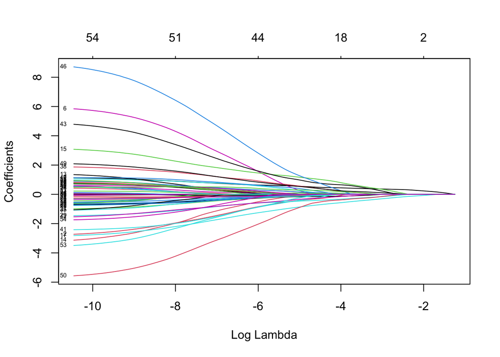

```r
#lets compare lasso and ridge coefficients
plot(lasso.fit, xvar="lambda", label=T)
```

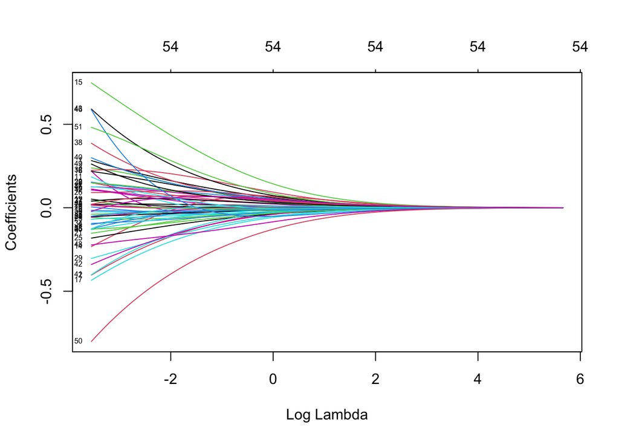

```r
plot(ridge.fit, xvar = "lambda", label = TRUE)
```

#### Example 3 - Elastic net regression with cross-validation

```r
# Fit elastic net model
elastic.fit = cv.glmnet(x = feature.matrix,      # features = all cytokines
                   y = response.vector,          # binary response
                   family = 'binomial',          # we are doing binary classification
                   nfolds = 5,
                   type.measure = 'auc',
                   alpha = 0.5)

# Use the fit model to predict on the testing data
elastic.preds = predict(elastic.fit, newx = testing.matrix, type = 'class')

# Take a look at how our model did
elastic.metrics = ReportPerfMetrics(elastic.preds[,ncol(elastic.preds)], test.data$Response, 'obese')
table(Predicted_Group = elastic.preds[,ncol(elastic.preds)],
      Actual_Group = test.data$Response)
```

```
##                Actual_Group
## Predicted_Group normal obese
##          normal     48    16
##          obese       1    17
```

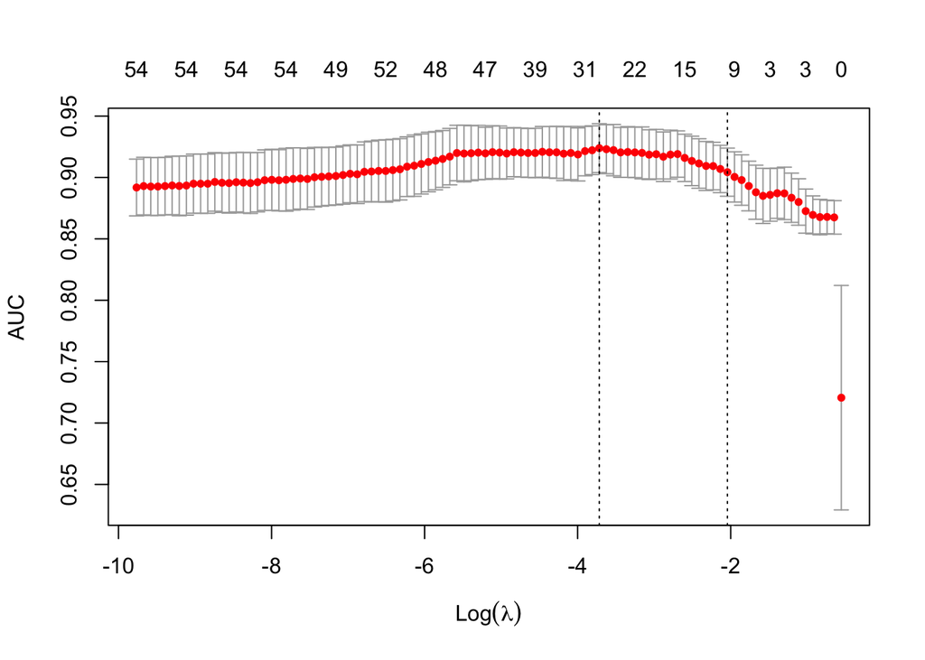

```r
# Plot the cross-validation curve, and upper and lower standard deviation curves, as a function of the lambda values used
plot(elastic.fit)
```

### Sparse Linear Regression Evaluation

For discussion on the alpha and lambda parameters, check out this [review of `glmnet` and elastic net regression](http://www.moseslab.csb.utoronto.ca/alan/glmnet_presentation.pdf).

```r
# Compare the 3 examples, alpha = 0, alpha = 1, and alpha = 0.5
results = cbind(Ridge = ridge.metrics, Lasso = lasso.metrics, ElasticNet = elastic.metrics)
results
```

```
##           Ridge     Lasso     ElasticNet
## Accuracy  0.7195122 0.7195122 0.7926829
## Precision 0.6923077 0.6785714 0.9444444
## Recall    0.5454545 0.5757576 0.5151515
```

```r
######### Find optimal alpha and lambda with caret cross-validation
# Construct object for holding training parameters
my.train.control = trainControl(method = "repeatedcv", number = 5, returnResamp = "all")

# Train an elastic net model with varying alpha and lambda
model = train(Response ~ ., data = train.data,
               method = "glmnet",                                        # Fit an elastic net model
               metric = "Accuracy",                                      # Use accuracy as the loss for cross validation
               tuneGrid = expand.grid(.alpha = seq(0, .5, by = .05),     # Try these alpha values
                                      .lambda = seq(0, 1, by = .05)),    # And these lambda values
               trControl = my.train.control)
model
```

```
## glmnet
##
## 244 samples
##  54 predictor
##   2 classes: 'normal', 'obese'
##
## No pre-processing
## Resampling: Cross-Validated (5 fold, repeated 1 times)
## Summary of sample sizes: 195, 195, 195, 196, 195
## Resampling results across tuning parameters:
##
##   alpha  lambda  Accuracy   Kappa
##   0.00   0.00    0.8236395   0.624404198
##   0.00   0.05    0.8277211   0.632679152
##   0.00   0.10    0.8278061   0.627654156
##   0.00   0.15    0.8278912   0.625932122
##   0.00   0.20    0.8360544   0.643505302
##   0.00   0.25    0.8278061   0.623329157
##   0.00   0.30    0.8237245   0.615459625
##   0.00   0.35    0.8278061   0.623329157
##   0.00   0.40    0.8318878   0.631817502
##   0.00   0.45    0.8318878   0.631817502
##   0.00   0.50    0.8319728   0.630277697
##   0.00   0.55    0.8197279   0.601777540
##   0.00   0.60    0.8073129   0.572629258
##   0.00   0.65    0.8033163   0.559991171
##   0.00   0.70    0.7909864   0.530406505
##   0.00   0.75    0.7950680   0.538513672
##   0.00   0.80    0.7868197   0.518017138
##   0.00   0.85    0.7827381   0.507853709
##   0.00   0.90    0.7786565   0.497652199
##   0.00   0.95    0.7745748   0.487928422
##   0.00   1.00    0.7704932   0.477509016
##   0.05   0.00    0.8071429   0.590303295
##   0.05   0.05    0.8318027   0.641666508
##   0.05   0.10    0.8401361   0.653892090
##   0.05   0.15    0.8360544   0.643388502
##   0.05   0.20    0.8319728   0.634002643
##   0.05   0.25    0.8360544   0.640612687
##   0.05   0.30    0.8278061   0.621166771
```

[output cut: 191 more lines]

```
##   0.50   0.45    0.6147959   0.000000000
##   0.50   0.50    0.6147959   0.000000000
##   0.50   0.55    0.6147959   0.000000000
##   0.50   0.60    0.6147959   0.000000000
##   0.50   0.65    0.6147959   0.000000000
##   0.50   0.70    0.6147959   0.000000000
##   0.50   0.75    0.6147959   0.000000000
##   0.50   0.80    0.6147959   0.000000000
##   0.50   0.85    0.6147959   0.000000000
##   0.50   0.90    0.6147959   0.000000000
##   0.50   0.95    0.6147959   0.000000000
##   0.50   1.00    0.6147959   0.000000000
##
## Accuracy was used to select the optimal model using the largest value.
## The final values used for the model were alpha = 0.2 and lambda = 0.1.
```

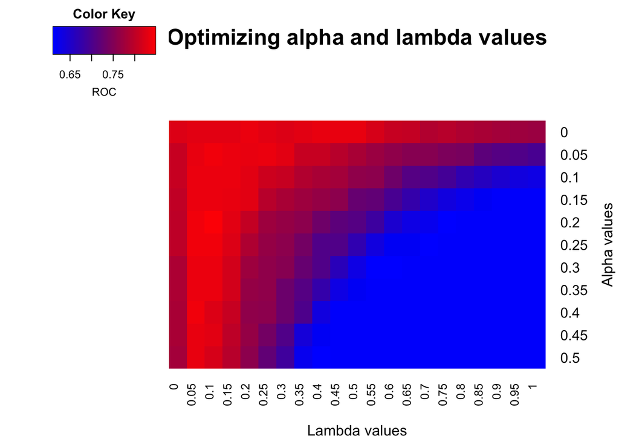

```r
# Reshape the data into a matrix for making a heatmap
model.results = model$results
model.cast = dcast(model.results, alpha ~ lambda, value.var = 'Accuracy')
row.names(model.cast) = model.cast$alpha
model.cast$alpha = NULL

# Make a heatmap of the alphas and lambdas
my.palette <- colorRampPalette(c("blue", "red"))(n = 100)
heatmap.2(as.matrix(model.cast),
          col = my.palette,           # Define heatmap colors
          Rowv = F, Colv = F,         # Don't cluster/reorder rows or columns
          dendrogram = 'none',        # Don't plot dendrogram
          trace = 'none',             # Don't draw trace lines
          density.info = 'none',      # Don't draw histogram on color key
          key.xlab = 'ROC',           # Label the color key
          main = 'Optimizing alpha and lambda values',
          xlab = 'Lambda values',
          ylab = 'Alpha values')
```

### Random Forest

This is a nice reference for the basics on the [Random Forest](https://www.simplilearn.com/tutorials/data-science-tutorial/random-forest-in-r). You can also review the [Statquest](https://www.youtube.com/watch?v=J4Wdy0Wc_xQ&t=1s) on Random Forests.

```r
# Fitting Random Forest to the train dataset
set.seed(120)  # Setting seed
classifier_RF = randomForest(x = feature.matrix,
                             y = response.vector,
                             ntree = 500)
classifier_RF
```

```
##
## Call:
##  randomForest(x = feature.matrix, y = response.vector, ntree = 500)
##                Type of random forest: classification
##                      Number of trees: 500
## No. of variables tried at each split: 7
##
##         OOB estimate of  error rate: 14.75%
## Confusion matrix:
##        normal obese class.error
## normal    133    17   0.1133333
## obese      19    75   0.2021277
```

```r
# Predicting the Test set results
y_pred = predict(classifier_RF, newdata = testing.matrix)

# Confusion Matrix
confusion_mtx = table(testing.response, y_pred)
confusion_mtx
```

```
##                 y_pred
## testing.response normal obese
##           normal     44     5
##           obese      14    19
```

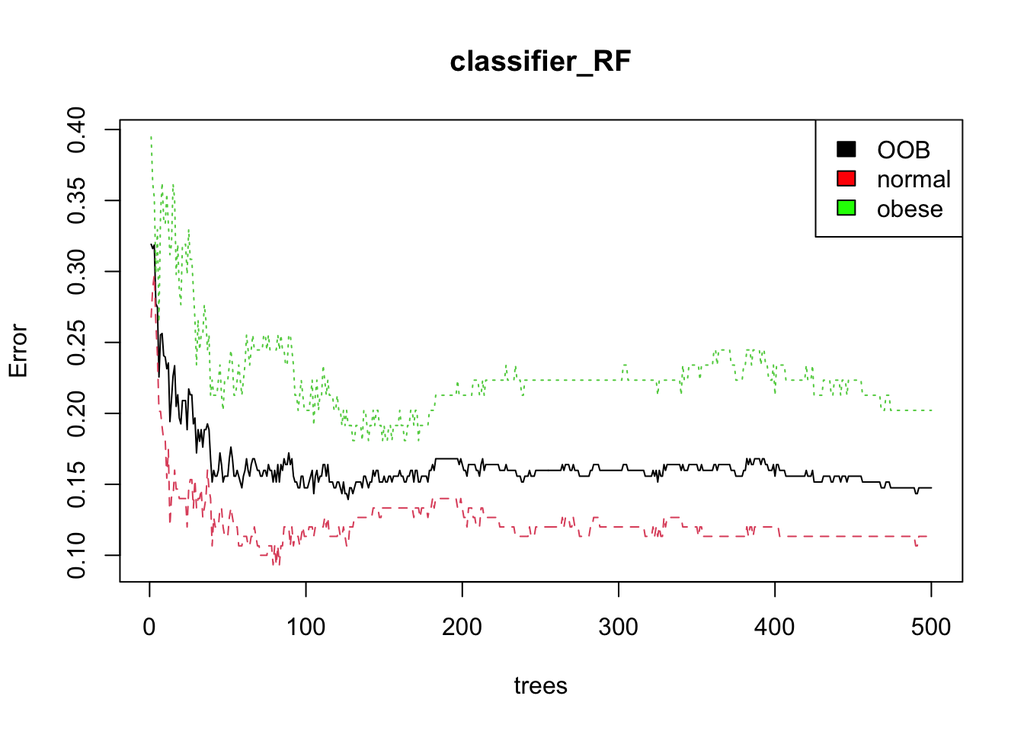

```r
# Plotting model
plot(classifier_RF)
legend("topright", legend=colnames(classifier_RF$err.rate), fill=c("black", "red", "green"))
```

```r
# Importance plot
importance(classifier_RF)
```

```
##                MeanDecreaseGini
## CRP                  15.6193807
## Eotaxin               1.0046782
## Eotaxin-3             0.9898209
## FGF (basic)           1.0344528
## GM-CSF                1.2285810
## ICAM-1                1.5352226
## IFN-alpha2a           1.2243551
## IFN-beta              1.9835899
## IFN-gamma             1.2825096
## IL-10                 1.0606659
## IL-12/IL-23p40        1.1857533
## IL-12p70              1.0795111
## IL-13                 1.9410694
## IL-15                 1.7597358
## IL-16                 2.7066171
## IL-17A                1.1462027
## IL-17B                8.8506852
## IL-17C                0.9486540
## IL-17D                1.0912873
## IL-1alpha             0.9062149
## IL-1beta              1.3012124
## IL-1RA                3.1073592
## IL-2                  1.1720945
## IL-22                 1.1715765
## IL-23                 1.9045690
## IL-27                 1.7269545
## IL-29                 0.9989713
## IL-3                  1.0842489
## IL-31                 2.0192832
## IL-4                  1.2391218
## IL-5                  0.9021296
## IL-6                  9.1217559
## IL-7                  1.1104827
## IL-8                  1.1569940
## IL-9                  1.2273450
## IP-10                 1.3400187
## MCP-1                 0.9864828
## MCP-4                 1.5263360
## MDC                   1.1377151
## MIP-1alpha            1.2432459
## MIP-1beta             1.0240320
## MIP-3alpha            1.2420149
## PlGF                  1.2966943
## SAA                   8.2010410
## TARC                  1.3709941
## Tie-2                 1.4711967
## TNF-alpha             1.1142316
## TNF-beta              3.4721424
## TSLP                  2.6774064
## VCAM-1                2.6075694
## VEGF-A                2.9939402
## VEGF-C                1.2370080
## VEGF-D                1.2185059
## VEGFR-1/Flt-1         0.9895191
```

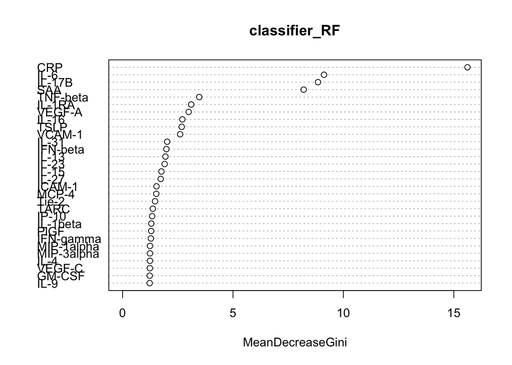

```r
# Variable importance plot
varImpPlot(classifier_RF)
```